# ScPoEconometrics 3

Florian Oswald  
2018-10-05

### Data On Cars

- Suppose we had data on car `speed` and stopping `dist` (ance):

```r
head(cars)
```

```
  speed dist
1     4    2
2     4   10
3     7    4
4     7   22
5     8   16
6     9   10
```

- How are `speed` and `dist` related?

### Scatterplot of Cars

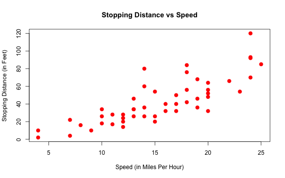

- What's a reasonable **summary** of this relationship?

### A Line throught the Scatterplot of Cars

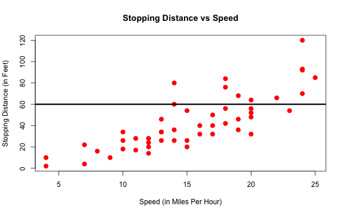

- *A line*. Great. But **which** line? This one?
- That's a *flat* line. But `dist` is increasing. :-(

### A Line throught the Scatterplot of Cars

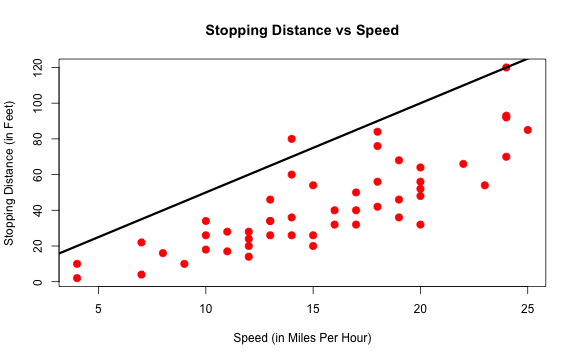

- **That** one?
- Slightly better. Has a *slope* and an *intercept*.

### Writing Down A Line

- We observe \( (y_i,x_i) \) in the data.
- Here is a formula that describes their relationship: \[ y_i = b_0 + b_1 x_i + e_i \]
- How to choose \( b_0 \) and \( b_1 \) s.t. this is **best** line?

### Prediction and Errors

- We need to denote the *output* of the line.
- We call the value \( \widehat{y}_i \) the *predicted value*, after we choose values for \( b_0,b_1 \) and \( x \). \[ \widehat{y}_i = b_0 + b_1 x_i \]
- In general, we **expect** to make errors!

### Towards The Best Line

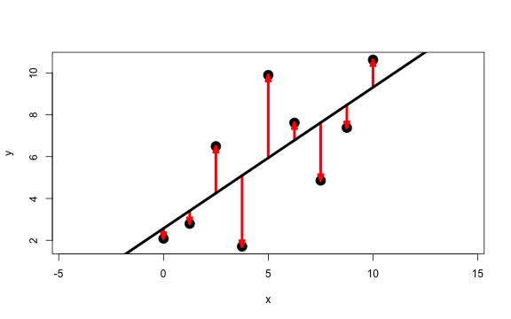

- Red Arrows are *errors* or *residuals* (often \( u \) or \( e \))

### App Time!

```r
library(ScPoEconometrics) # load our library
launchApp('reg_simple_arrows')
aboutApp('reg_simple_arrows')
```

### Writing Down The Best Line

- choose \( (b_0,b_1) \) s.t. the sum \( e_1^2 + \dots + e_N^2 \) is **as small as possible**
- \( e_1^2 + \dots + e_N^2 \) is the *sum of squared residuals*, or SSR.
- Wait a moment… Why *squared* residuals?!

### Best Line and Squared Errors

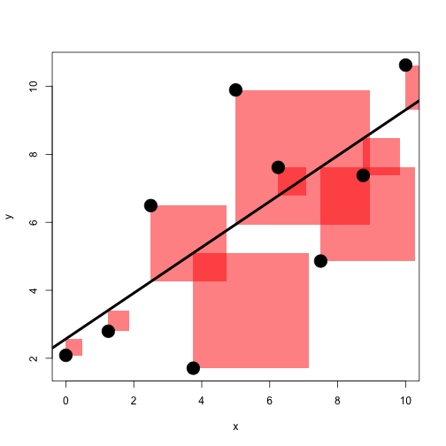

### App Time!

```r
launchApp('reg_simple')
aboutApp('reg_simple')
```

### Ordinary Least Squares (OLS)

- OLS estimates the best line for us.
- In our single regressor case, there is a simple formula for the slope: \[ b_1 = \frac{cov(x,y)}{var(x)} \]
- and for the intercept \[ b_0 = \bar{y} - b_1\bar{x} \]

### App Time!

How does OLS actually perform the minimization problem?

```r
launchApp('SSR_cone')
aboutApp('SSR_cone')  # after
```

### App Time!

Let's do some more OLS!

```r
launchApp('reg_full')
aboutApp('reg_full')  # after
```

### Common Restrictions on OLS

- There are some common *flavors* of OLS.
- We will go through some of them.
- E.g. what happens without an intercept?
- Or, what happens if we *demean* both \( y \) and \( x \)?

### OLS without any Regressor

- Our line is flat at level \( b_0 \): \[ y = b_0 \]
- Our optimization problem is now \[ b_0 = \arg\min_{\text{int}} \sum_{i=1}^N \left[y_i - \text{int}\right]^2, \]
- With solution \[ b_0 = \frac{1}{N} \sum_{i=1}^N y_i = \overline{y}. \]

### Regression without Intercept

- Now we have a line anchored at the origin.
- The OLS slope estimate becomes \[ \begin{align} b_1 &= \arg\min_{\text{slope}} \sum_{i=1}^N \left[y_i - \text{slope } x_i \right]^2\\ \mapsto b_1 &= \frac{\frac{1}{N}\sum_{i=1}^N x_i y_i}{\frac{1}{N}\sum_{i=1}^N x_i^2} = \frac{\bar{x} \bar{y}}{\overline{x^2}} \end{align} \]

### App: Regressions w/o Slope or Intercept

```r
launchApp('reg_constrained')
```

### Centering a Regression

- *centering* or *demeaning* means to substract the mean.
- We get \( \widetilde{y}_i = y_i - \bar{y} \).
- Let's run a regression *without* intercept as above using \( \widetilde{y}_i,\widetilde{x}_i \)
- We get \[ \begin{align} b_1 &= \frac{\frac{1}{N}\sum_{i=1}^N \widetilde{x}_i \widetilde{y}_i}{\frac{1}{N}\sum_{i=1}^N \widetilde{x}_i^2}\\ &= \frac{cov(x,y)}{var(x)} \end{align} \]

### App: demeaned regression

```r
launchApp('demeaned_reg')
```

### Standardizing a Regression

- To standardize \( z \) means to do \( \breve{z}=\frac{z-\bar{z}}{sd(z)} \)
- I.e. substract the variable's mean and divide by its standard deviation.
- Proceed as above, but with \( \breve{y}_i,\breve{x}_i \)
- We get \[ \begin{align} b_1 &= \frac{\frac{1}{N}\sum_{i=1}^N \breve{x}_i \breve{y}_i}{\frac{1}{N}\sum_{i=1}^N \breve{x}_i^2}\\ &= \frac{Cov(x,y)}{\sigma_x \sigma_y}=Corr(x,y) \end{align} \]

### App: Standardized regression

```r
launchApp('reg_standardized')
```

### Predictions and Residuals

1. The error is \( e_i = y_i - \widehat{y}_i \)
2. The average of \( \widehat{y}_i \) is equal to \( \bar{y} \). \[ \begin{align} \frac{1}{N} \sum_{i=1}^N \widehat{y}_i &= \frac{1}{N} \sum_{i=1}^N b_0 + b_1 x_i \\ &= b_0 + b_1 \bar{x} = \bar{y}\\ \end{align} \]
3. Then, \[ \frac{1}{N} \sum_{i=1}^N e_i = \bar{y} - \frac{1}{N} \sum_{i=1}^N \widehat{y}_i = 0 \] i.e. the average of errors is zero.

### Prediction and Errors are Orthogonal

- This is the data of the above plots (arrows and squares):

```
      x     y y_hat error
1  0.00  2.09  2.57 -0.48
2  1.25  2.79  3.41 -0.62
3  2.50  6.49  4.25  2.24
4  3.75  1.71  5.10 -3.39
5  5.00  9.89  5.94  3.95
6  6.25  7.62  6.78  0.83
7  7.50  4.86  7.63 -2.77
8  8.75  7.38  8.47 -1.09
9 10.00 10.63  9.31  1.32
```

1. The average of \( \widehat{y}_i \) is the same as the mean of \( y \).
2. The average of the errors should be zero.
3. Prediction and errors should be *uncorrelated* (i.e. orthogonal).

### Prediction and Errors are Orthogonal

```r
# 1.
all.equal(mean(ss$error), 0)
```

```
[1] TRUE
```

```r
# 2.
all.equal(mean(ss$y_hat), mean(ss$y))
```

```
[1] TRUE
```

```r
# 3.
all.equal(cov(ss$error,ss$y_hat), 0)
```

```
[1] TRUE
```

### Linear Statistics

- It's important to keep in mind that Var, Cov, Corr and Regression measure **linear relationships** between two variables.
- Two datasets with *identical* correlations could look *vastly* different.
- They would have the same regression line.
- Same correlation coefficient.
- Is that even possible?

### Linear Statistics: Anscombe

- Francis Anscombe (1973) comes up with 4 datasets with identical stats. But look!

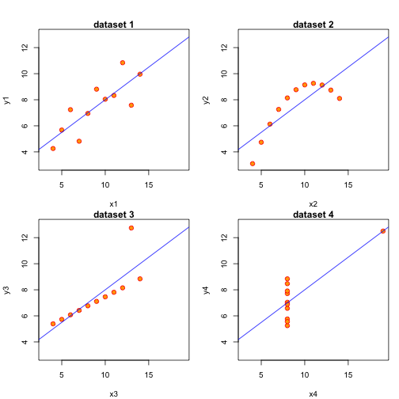

### Dinosaurs in your Data?

- So, be wary of only looking a linear summary stats.
- Also look at plots.
- Dinosaurs?

  ```r
  launchApp("datasaurus")
  aboutApp("datasaurus")
  ```

### Nonlinear Relationships in Data?

- We can accomodate non-linear relationships in regressions.
- We'd just add a higher order term like this: \[ y_i = b_0 + b_1 x_i + b_2 x_i^2 + e_i \]
- This is *multiple regression* (next chapter!)

### Nonlinear Relationships in Data?

- For example, suppose we had this data and fit the above regression:

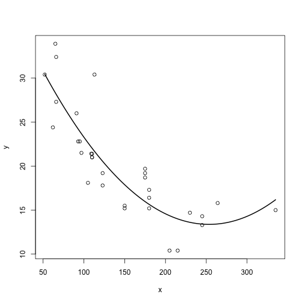

### Analysis of Variance

- Remember that \( y_i = \widehat{y}_i + e_i \).
- We have the following decomposition: \[ \begin{align} Var(y) &= Var(\widehat{y} + e)\\ &= Var(\widehat{y}) + Var(e) + 2 Cov(\widehat{y},e)\\ &= Var(\widehat{y}) + Var(e) \end{align} \]
- Because: \( Cov(\hat{y},e)=0 \)
- Total variation (SST) = Model explained (SSE) + Unexplained (SSR)

### Assessing the Goodness of Fit

- The \( R^2 \) measures how good the model fits the data.
- \( R^2=1 \) is very good, \( R^2=0 \) is very poorly. \[ R^2 = \frac{\text{variance explained}}{\text{total variance}} = \frac{SSE}{SST} = 1 - \frac{SSR}{SST}\in[0,1] \]
- Small \( R^2 \) doesn't mean it's a useless model!

### An Example - California Test Scores

- Let's look at [the worked example](https://scpoecon.github.io/ScPoEconometrics/linreg.html#lm-example1) in the book!

### Rescaling Regressions

- Suppose outcome \( y \) is *income in Euros*
- \( x \) be years of schooling \[ y_i = \beta_0 + \beta_1 x_i + \varepsilon_i \]
- Assume that \( \beta_1 = 2000 \), s.t. each additional year of schooling gives 2000 Euros more income.
- What is \( \beta_1 \) if we measure \( y \) in *thousands of euros* instead?

### App: Rescaling Regressors

```r
library(ScPoEconometrics)
launchApp('Rescale')
```

### Tutorial: Rescaling Regressors

```r
library(ScPoEconometrics)
runTutorial('rescaling')
```